# trantract: extract and visualize transit information by census tract

**NB**: This package requires a dev version of `ggmap()` to avoid to avoid the following error:

```
Error: GeomRasterAnn was built with an incompatible version of
ggproto.  Please reinstall the package that provides this extension.
```

You can use the following command to install the dev version of `ggmap()`:

```
install_github("dkahle/ggmap")
```

See the following URL for more information:

http://www.arilamstein.com/blog/2017/01/16/choroplethr-v3-5-3-now-cran/

The trantract package enables you to explore and visualize how King Country Metro transit service is related to the spatial characteristics of US Census Bureau census tracts. The package also includes a data set of some demographic information associated with census tracts that can be explored as well.

In this vignette, we'll use the functionality and data in the package to create a measure of the level of transit service (“route-stops”) and see how that measure varies across census tracts. We'll then perform some simple modeling to see if there is any clear relationship between level of service and certain demographic variables.

Load the library

```r
library( trantract )
```

Load the data sets

```r
data( stops )
data( kct.shp.proj )
data( route.stops.df )
data( tract.demographics.kc )
```

Get a list of all census tracts.

```r
census.tracts <- unique( stops$tract )
```

For each tract, get the count of how many route-stops there are in the tract. For example, if a stop is served by four routes, that equates to four route-stops.

Basically, we are creating a measure of how well King County metro serves that tract.

Create a DF that initially has one column: the census tracts.

```r
service.distro.df <- data.frame( tract = census.tracts )

route.stops.vec <- numeric( 0 )
```

For each tract, determine the number of route-stops.

```r
for( tract in service.distro.df$tract ) {

  route.stops.vec[ tract ] <- nrow( route_stops_from_census_tract( tract ) )

}
```

Add the route-stops as a column to our service DF

```r
service.distro.df$route.stops <- route.stops.vec
```

See how the level of service is distributed.

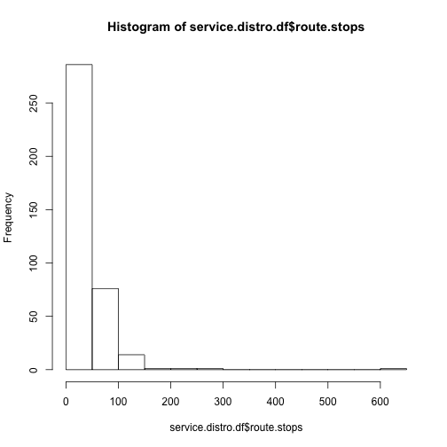

```r
hist( service.distro.df$route.stops )
```

That is pretty skewed. Try a log transform.

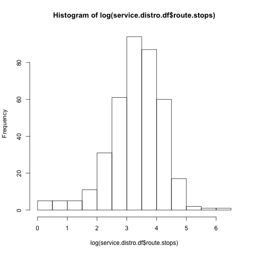

```r
hist( log( service.distro.df$route.stops ) )
```

Get the min and max and look at those census tracts

```r
service.distro.df[ service.distro.df$route.stops == min( service.distro.df$route.stops ), ]
```

```
##      tract route.stops
## 263 320.07           1
## 281 321.02           1
## 347 323.28           1
## 348 323.27           1
## 373    301           1
```

```r
service.distro.df[ service.distro.df$route.stops == max( service.distro.df$route.stops ), ]
```

```
##    tract route.stops
## 23    81         628
```

[figure not shown]

```r
plot_tract( 320.07, map.zoom = 13 )
```

[figure not shown]

```r
plot_tract( 81, map.zoom = 15 )
```

Now let's look at how our measure of service relates to some demographic information.

The Census.Tract column in the demographic data is character, not factor. So create a similar column in our data to facilitate the merge.

```r
service.distro.df$Tract <- as.character( service.distro.df$tract )
tract.demographics.kc.routes <- merge( tract.demographics.kc, service.distro.df )
```

First, we'll regress against: total population of the tract, total housing units, and total land area.

```r
mod.tract.multivar <- lm( route.stops ~ Population + Housing.Units + Land.Area, data = tract.demographics.kc.routes )
summary( mod.tract.multivar )
```

```
##
## Call:
## lm(formula = route.stops ~ Population + Housing.Units + Land.Area,
##     data = tract.demographics.kc.routes)
##
## Residuals:
##    Min     1Q Median     3Q    Max
## -65.68 -17.55  -7.57   7.35 558.18
##
## Coefficients:
##                Estimate Std. Error t value Pr(>|t|)
## (Intercept)   25.055170   7.314894   3.425 0.000682 ***
## Population    -0.008044   0.002190  -3.674 0.000274 ***
## Housing.Units  0.025011   0.004167   6.002 4.58e-09 ***
## Land.Area     -0.096441   0.076073  -1.268 0.205673
## ---
## Signif. codes:  0 '***' 0.001 '**' 0.01 '*' 0.05 '.' 0.1 ' ' 1
##
## Residual standard error: 41.47 on 376 degrees of freedom
## Multiple R-squared:  0.09526,    Adjusted R-squared:  0.08804
## F-statistic:  13.2 on 3 and 376 DF,  p-value: 3.29e-08
```

That is not a very compelling model.

Let's just regress against the values for density in our demographic data set.

[output not shown]

Interestingly, that doesn't give a strong relationship either.

Visualize it.

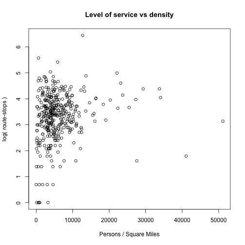

```r
plot(
     tract.demographics.kc.routes$Population.Density,
     log( tract.demographics.kc.routes$route.stops ),
     main = "Level of service vs density",
     xlab = "Persons / Square Miles",
     ylab = "log( route-stops )"
     )
```

People often say that transit is planned around “urban density” but from these simple regressions, it appears that there must other factors as well.

Let's keep going.

Change the response variable so that we aren't just looking at number of route-stops, but the *density* of route-stops; not all census tracts are the same size.

Add a column that represents the density of the route.stops in each tract.

Note, again, that stops in and of themselves are *not* a good measure of service because of the wide variation in the number of buses that serve any given stop. And even this is a simplification because we aren't considering number of trips that any given bus makes to that stop each day–what most people would think of as frequency.

```r
tract.demographics.kc.routes$route.stops.dens <- tract.demographics.kc.routes$route.stops / tract.demographics.kc.routes$Land.Area
```

Let's also use the lat-lon, but we will normalize these.

```r
mean.INTPTLAT10 <- mean( tract.demographics.kc.routes$INTPTLAT10 )
sd.INTPTLAT10   <- sd(   tract.demographics.kc.routes$INTPTLAT10 )

mean.INTPTLON10 <- mean( tract.demographics.kc.routes$INTPTLON10 )
sd.INTPTLON10   <- sd(   tract.demographics.kc.routes$INTPTLON10 )

norm_lat <- function( lat.arg ) {

  ( lat.arg - mean.INTPTLAT10 ) / sd.INTPTLAT10

}

norm_lon <- function( lon.arg ) {

  ( lon.arg - mean.INTPTLON10 ) / sd.INTPTLON10

}

tract.demographics.kc.routes$norm.intptlat10 <- norm_lat( tract.demographics.kc.routes$INTPTLAT10 )
tract.demographics.kc.routes$norm.intptlon10 <- norm_lon( tract.demographics.kc.routes$INTPTLON10 )
```

How many tracts are “north” and “south” of zero.

```r
sum( tract.demographics.kc.routes$norm.intptlat10 < 0 )
```

```
## [1] 170
```

```r
sum( tract.demographics.kc.routes$norm.intptlat10 > 0 )
```

```
## [1] 210
```

We've set the stage, let's rock a few more regressions.

## Density of route.stops as the response variable

```r
mod.tract.rs.dens.density <- lm( route.stops.dens ~ Population.Density, data = tract.demographics.kc.routes )
summary( mod.tract.rs.dens.density )
```

```
##
## Call:
## lm(formula = route.stops.dens ~ Population.Density, data = tract.demographics.kc.routes)
##
## Residuals:
##     Min      1Q  Median      3Q     Max
## -401.50  -23.85   -7.33    8.73 1827.20
##
## Coefficients:
##                      Estimate Std. Error t value Pr(>|t|)
## (Intercept)        -11.196913   8.853429  -1.265    0.207
## Population.Density   0.011504   0.001057  10.887   <2e-16 ***
## ---
## Signif. codes:  0 '***' 0.001 '**' 0.01 '*' 0.05 '.' 0.1 ' ' 1
##
## Residual standard error: 118.5 on 378 degrees of freedom
## Multiple R-squared:  0.2387, Adjusted R-squared:  0.2367
## F-statistic: 118.5 on 1 and 378 DF,  p-value: < 2.2e-16
```

Wow. Okay. That made a difference! The R-Squared is now 0.24.

Try quadratic and cubic functions of the population density.

### Quadratic

```r
mod.tract.rs.dens.density.quad <- lm( route.stops.dens ~ poly( Population.Density, 2, raw = TRUE ), data = tract.demographics.kc.routes )
summary( mod.tract.rs.dens.density.quad )
```

```
##
## Call:
## lm(formula = route.stops.dens ~ poly(Population.Density, 2, raw = TRUE),
##     data = tract.demographics.kc.routes)
##
## Residuals:
##     Min      1Q  Median      3Q     Max
## -306.77  -28.46   -8.15   16.97 1805.65
##
## Coefficients:
##                                            Estimate Std. Error t value Pr(>|t|)
## (Intercept)                              -3.354e+01  1.195e+01  -2.805  0.00529 **
## poly(Population.Density, 2, raw = TRUE)1  1.729e-02  2.349e-03   7.362 1.15e-12 ***
## poly(Population.Density, 2, raw = TRUE)2 -1.837e-07  6.674e-08  -2.752  0.00621 **
## ---
## Signif. codes:  0 '***' 0.001 '**' 0.01 '*' 0.05 '.' 0.1 ' ' 1
##
## Residual standard error: 117.5 on 377 degrees of freedom
## Multiple R-squared:  0.2537, Adjusted R-squared:  0.2497
## F-statistic: 64.08 on 2 and 377 DF,  p-value: < 2.2e-16
```

### Cubic

```r
mod.tract.rs.dens.density.cube <- lm( route.stops.dens ~ poly( Population.Density, 3, raw = TRUE ), data = tract.demographics.kc.routes )
summary( mod.tract.rs.dens.density.cube )
```

```
##
## Call:
## lm(formula = route.stops.dens ~ poly(Population.Density, 3, raw = TRUE),
##     data = tract.demographics.kc.routes)
##
## Residuals:
##     Min      1Q  Median      3Q     Max
## -366.23  -18.14   -5.15    6.36 1810.14
##
## Coefficients:
##                                            Estimate Std. Error t value Pr(>|t|)
## (Intercept)                               4.460e+00  1.467e+01   0.304 0.761325
## poly(Population.Density, 3, raw = TRUE)1  2.410e-03  4.164e-03   0.579 0.563138
## poly(Population.Density, 3, raw = TRUE)2  9.661e-07  2.762e-07   3.498 0.000525 ***
## poly(Population.Density, 3, raw = TRUE)3 -1.910e-11  4.459e-12  -4.284 2.33e-05 ***
## ---
## Signif. codes:  0 '***' 0.001 '**' 0.01 '*' 0.05 '.' 0.1 ' ' 1
##
## Residual standard error: 114.9 on 376 degrees of freedom
## Multiple R-squared:  0.2884, Adjusted R-squared:  0.2828
## F-statistic:  50.8 on 3 and 376 DF,  p-value: < 2.2e-16
```

How do these three compare when measured with `AIC()`?

```r
AIC( mod.tract.rs.dens.density, mod.tract.rs.dens.density.quad, mod.tract.rs.dens.density.cube )
```

```
##                                df      AIC
## mod.tract.rs.dens.density       3 4711.475
## mod.tract.rs.dens.density.quad  4 4705.916
## mod.tract.rs.dens.density.cube  5 4689.807
```

In StatR 501, they said that a difference in AIC > 10 was strong evidence that a model was better. On that basis, we would choose the cubic model.

## Visualizations of route-stop density regressions

Get the slope and intercept from our linear regression

```r
slope     <- coef( mod.tract.rs.dens.density )[ "Population.Density" ]
intercept <- coef( mod.tract.rs.dens.density )[ "(Intercept)" ]
```

Get the route stop density for the tract with the greatest population density.

```r
( max.pop.dens <- max( tract.demographics.kc.routes$Population.Density ) )
```

```
## [1] 51128.16
```

```r
( rs.dens.for.max.pop.dens <- tract.demographics.kc.routes[ tract.demographics.kc.routes$Population.Density == max.pop.dens, ]$route.stops.dens )
```

```
## [1] 230
```

Get the population density for the tract that has the greatest density of route stops.

```r
( max.rs.dens <- max( tract.demographics.kc.routes$route.stops.dens ) )
```

```
## [1] 1962.5
```

```r
( pop.dens.for.max.service <- tract.demographics.kc.routes[ tract.demographics.kc.routes$route.stops.dens == max.rs.dens, ]$Population.Density )
```

```
## [1] 12734.13
```

Prepare the points so that we can add our polynomial curve.

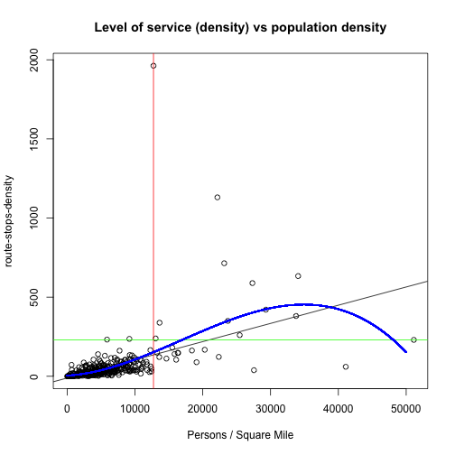

```r
cube.coef <- coef( mod.tract.rs.dens.density.cube )
x.cube <- 0:50000
y.cube <- vapply( 0:50000, function( x ) y = cube.coef[ 4 ] * ( x ** 3 ) + cube.coef[ 3 ] * ( x ** 2 ) + cube.coef[ 2 ] * ( x ) + cube.coef [ 1 ], numeric( 1 ) )

plot(
     tract.demographics.kc.routes$Population.Density,
     tract.demographics.kc.routes$route.stops.dens,
     main = "Level of service (density) vs population density",
     xlab = "Persons / Square Mile",
     ylab = "route-stops-density"
     )

abline( intercept, slope )

abline( v = pop.dens.for.max.service, col = "red" )
abline( h = rs.dens.for.max.pop.dens, col = "green" )

points( x.cube, y.cube, cex = 0.10, col = "blue" )
```

Use log() scale for the y-axis.

```r
( log.rs.dens.for.max.pop.dens <- log( rs.dens.for.max.pop.dens ) )
```

```
## [1] 5.438079
```

```r
log.y.cube <- log( y.cube )
```

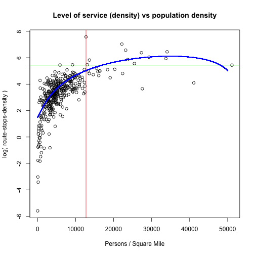

```r
plot(
     tract.demographics.kc.routes$Population.Density,
     log( tract.demographics.kc.routes$route.stops.dens ),
     main = "Level of service (density) vs population density",
     xlab = "Persons / Square Mile",
     ylab = "log( route-stops-density )"
     )

abline( v = pop.dens.for.max.service, col = "red" )
abline( h = log.rs.dens.for.max.pop.dens, col = "green" )

points( x.cube, log.y.cube, cex = 0.10, col = "blue" )
```

## Regress against the normalized lat and lon

```r
mod.tract.latlon <- lm( route.stops.dens ~ norm.intptlat10 + norm.intptlon10, data = tract.demographics.kc.routes )
summary( mod.tract.latlon )
```

```
##
## Call:
## lm(formula = route.stops.dens ~ norm.intptlat10 + norm.intptlon10,
##     data = tract.demographics.kc.routes)
##
## Residuals:
##     Min      1Q  Median      3Q     Max
##  -97.04  -40.11  -19.26    3.58 1875.47
##
## Coefficients:
##                 Estimate Std. Error t value Pr(>|t|)
## (Intercept)       58.865      6.761   8.706  < 2e-16 ***
## norm.intptlat10   16.402      6.801   2.412   0.0164 *
## norm.intptlon10  -27.728      6.801  -4.077 5.57e-05 ***
## ---
## Signif. codes:  0 '***' 0.001 '**' 0.01 '*' 0.05 '.' 0.1 ' ' 1
##
## Residual standard error: 131.8 on 377 degrees of freedom
## Multiple R-squared:  0.06112,    Adjusted R-squared:  0.05613
## F-statistic: 12.27 on 2 and 377 DF,  p-value: 6.877e-06
```

As with population density, let's try polynomial functions of the covariates.

### Quadratic

```r
mod.tract.latlon.quad <- lm( route.stops.dens ~ poly( norm.intptlat10, 2, raw = TRUE ) + poly( norm.intptlon10, 2, raw = TRUE ), data = tract.demographics.kc.routes )
summary( mod.tract.latlon.quad )
```

```
##
## Call:
## lm(formula = route.stops.dens ~ poly(norm.intptlat10, 2, raw = TRUE) +
##     poly(norm.intptlon10, 2, raw = TRUE), data = tract.demographics.kc.routes)
##
## Residuals:
##     Min      1Q  Median      3Q     Max
## -128.02  -39.91  -17.75    6.30 1861.25
##
## Coefficients:
##                                       Estimate Std. Error t value Pr(>|t|)
## (Intercept)                             71.877     10.002   7.186 3.62e-12 ***
## poly(norm.intptlat10, 2, raw = TRUE)1    8.072      7.456   1.083 0.279693
## poly(norm.intptlat10, 2, raw = TRUE)2  -16.370      6.624  -2.471 0.013899 *
## poly(norm.intptlon10, 2, raw = TRUE)1  -32.468      8.264  -3.929 0.000102 ***
## poly(norm.intptlon10, 2, raw = TRUE)2    3.323      3.143   1.057 0.291064
## ---
## Signif. codes:  0 '***' 0.001 '**' 0.01 '*' 0.05 '.' 0.1 ' ' 1
##
## Residual standard error: 130.9 on 375 degrees of freedom
## Multiple R-squared:  0.07934,    Adjusted R-squared:  0.06952
## F-statistic:  8.08 on 4 and 375 DF,  p-value: 2.944e-06
```

### Cubic

```r
mod.tract.latlon.cube <- lm( route.stops.dens ~ poly( norm.intptlat10, 3, raw = TRUE ) + poly( norm.intptlon10, 3, raw = TRUE ), data = tract.demographics.kc.routes )
summary( mod.tract.latlon.cube )
```

```
##
## Call:
## lm(formula = route.stops.dens ~ poly(norm.intptlat10, 3, raw = TRUE) +
##     poly(norm.intptlon10, 3, raw = TRUE), data = tract.demographics.kc.routes)
##
## Residuals:
##     Min      1Q  Median      3Q     Max
##  -98.79  -43.88  -14.80   11.79 1841.57
##
## Coefficients:
##                                       Estimate Std. Error t value Pr(>|t|)
## (Intercept)                             86.454     11.573   7.470 5.74e-13 ***
## poly(norm.intptlat10, 3, raw = TRUE)1   47.259     12.951   3.649 0.000301 ***
## poly(norm.intptlat10, 3, raw = TRUE)2  -36.392      8.494  -4.284 2.33e-05 ***
## poly(norm.intptlat10, 3, raw = TRUE)3  -21.623      5.878  -3.679 0.000269 ***
## poly(norm.intptlon10, 3, raw = TRUE)1  -31.941      8.149  -3.920 0.000105 ***
## poly(norm.intptlon10, 3, raw = TRUE)2   -3.030      7.703  -0.393 0.694317
## poly(norm.intptlon10, 3, raw = TRUE)3    1.003      1.285   0.780 0.435619
## ---
## Signif. codes:  0 '***' 0.001 '**' 0.01 '*' 0.05 '.' 0.1 ' ' 1
##
## Residual standard error: 128.9 on 373 degrees of freedom
## Multiple R-squared:  0.1121, Adjusted R-squared:  0.09777
## F-statistic: 7.845 on 6 and 373 DF,  p-value: 5.715e-08
```

And here are the `AIC()`.

```r
AIC( mod.tract.latlon, mod.tract.latlon.quad, mod.tract.latlon.cube )
```

```
##                       df      AIC
## mod.tract.latlon       4 4793.151
## mod.tract.latlon.quad  6 4789.701
## mod.tract.latlon.cube  8 4779.955
```

Based on the `AIC()`, the cubic model is outperforming the other two.

## Visualize the distribution of service across the lat-lon values.

Give each point one of three colors to represent its service level.

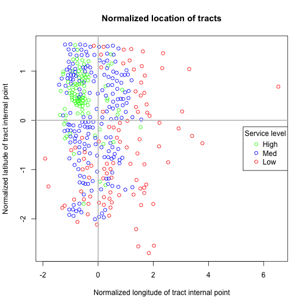

```r
log.rs.dens.5n  <- fivenum( log( tract.demographics.kc.routes$route.stops.dens ) )
tukey.low.hinge <- log.rs.dens.5n[ 2 ]
tukey.up.hinge  <- log.rs.dens.5n[ 4 ]

color.tukey <- function( val ) {
  ifelse( log( val ) < tukey.low.hinge, "red", ifelse( log( val ) > tukey.up.hinge, "green", "blue" ) )
}

tract.demographics.kc.routes$color <- color.tukey( tract.demographics.kc.routes$route.stops.dens )

plot( x = tract.demographics.kc.routes$norm.intptlon10,
      y = tract.demographics.kc.routes$norm.intptlat10,
      col = tract.demographics.kc.routes$color,
      main = "Normalized location of tracts",
      xlab = "Normalized longitude of tract internal point",
      ylab = "Normalized latitude of tract internal point"
    )

abline( h = 0, v = 0, col = "gray", lwd = 2, lty = 1 )

legend( x = "right", pch = 1, legend = c( "High", "Med", "Low" ), col = c( "green", "blue", "red" ), title = "Service level" )
```

What is interesting about this graph is that you can see instances where you have tracts with high service (green) adjacent to tracts with low service (red). One hopes that this is accounted for by other factors such as a pocket of low population density.

## Put it all together

```r
mod.tract.density.latlon.cube <- lm( route.stops.dens ~
                                       poly( Population.Density, 3, raw = TRUE ) +
                                       poly( norm.intptlat10, 3, raw = TRUE ) + poly( norm.intptlon10, 3, raw = TRUE ),
                                       data = tract.demographics.kc.routes
                                   )

summary( mod.tract.density.latlon.cube )
```

```
##
## Call:
## lm(formula = route.stops.dens ~ poly(Population.Density, 3, raw = TRUE) +
##     poly(norm.intptlat10, 3, raw = TRUE) + poly(norm.intptlon10,
##     3, raw = TRUE), data = tract.demographics.kc.routes)
##
## Residuals:
##     Min      1Q  Median      3Q     Max
## -361.60  -18.42   -6.00    9.51 1805.59
##
## Coefficients:
##                                            Estimate Std. Error t value Pr(>|t|)
## (Intercept)                               3.111e+01  2.308e+01   1.348 0.178489
## poly(Population.Density, 3, raw = TRUE)1 -1.530e-03  5.109e-03  -0.299 0.764736
## poly(Population.Density, 3, raw = TRUE)2  1.100e-06  3.054e-07   3.602 0.000359 ***
## poly(Population.Density, 3, raw = TRUE)3 -2.049e-11  4.753e-12  -4.310 2.09e-05 ***
## poly(norm.intptlat10, 3, raw = TRUE)1     1.356e+01  1.234e+01   1.099 0.272361
## poly(norm.intptlat10, 3, raw = TRUE)2    -1.237e+01  8.174e+00  -1.514 0.130954
## poly(norm.intptlat10, 3, raw = TRUE)3    -6.127e+00  5.569e+00  -1.100 0.271944
## poly(norm.intptlon10, 3, raw = TRUE)1    -8.652e+00  8.510e+00  -1.017 0.309958
## poly(norm.intptlon10, 3, raw = TRUE)2    -9.768e-01  7.111e+00  -0.137 0.890816
## poly(norm.intptlon10, 3, raw = TRUE)3     2.608e-01  1.188e+00   0.219 0.826395
## ---
## Signif. codes:  0 '***' 0.001 '**' 0.01 '*' 0.05 '.' 0.1 ' ' 1
##
## Residual standard error: 115.3 on 370 degrees of freedom
## Multiple R-squared:  0.2951, Adjusted R-squared:  0.278
## F-statistic: 17.21 on 9 and 370 DF,  p-value: < 2.2e-16
```

```r
AIC( mod.tract.density.latlon.cube )
```

```
## [1] 4698.212
```

When we combined population density with lat-lon, we seem to have lost all the benefit of lat-lon. The `AIC()` is not particularly better than using population density alone, nor is the R-Squared. Also, the p-values for the lat-lon terms are high, high.

This makes me think that to the extent that lat-lon was working, it was working because it somehow reflected population density information.

I think lat-lon is also problematic because Seattle is an isthmus–and a rather strangely-shaped isthmus because of Elliott Bay. It also has two significant inland bodies of water: Lake Union and Green Lake.

The next step in this investigation would be to somehow include service frequency information for each stop. I did not include that in my initial investigation because I didn't see any quick and easy way to extract it from the transit description files published by King County metro.